# EP1 - Applied Macroeconometrics

Monitor: Matheus Carrijo de Brito

02 agosto, 2022

### 0.0.1 Applied part

```r
tickers_names <- c("GNPC96", "UNRATE")

quantmod::getSymbols.FRED(Symbols = tickers_names, env = .GlobalEnv, return.class = "xts")
```

```
## [1] "GNPC96" "UNRATE"
```

```r
# Other way to download
#gnp_raw <- Quandl("FRED/GNPC96", type = 'xts')
#u_raw <- Quandl("FRED/UNRATE", type = 'xts')
```

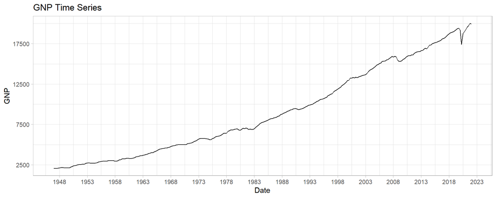

```r
# Plotting the product data

ggplot(data = GNPC96) +
  geom_line(aes(x = Index, y = GNPC96)) +
  scale_x_date(breaks = "5 years", date_labels = "%Y") +
  scale_y_continuous(breaks = seq(2500, 20000, by = 5000)) +
  labs(x = "Date", y = "GNP", title = "GNP Time Series") +
  theme_light()
```

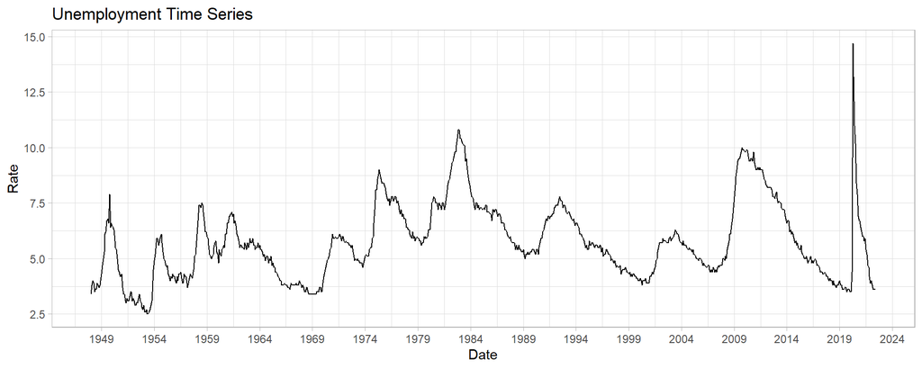

```r
# Plotting the unemployment data

ggplot(data = UNRATE) +
  geom_line(aes(x = Index, y = UNRATE)) +
  scale_x_date(breaks = "5 years", date_labels = "%Y") +
  scale_y_continuous(breaks = seq(2.5, 15, by = 2.5)) +
  labs(x = "Date", y = "Rate", title = "Unemployment Time Series") +
  theme_light()
```

```r
# Note that are required some transformation in data since unemployment is at monthly frequency and the GNP is on the level.

# Taking the difference in GNP

dgnp <- 100*diff(log(GNPC96), lag = 1) |> na.omit()

# Turning the data unemployment data quartely

u_quartely <- apply.quarterly(x = UNRATE, FUN = mean)

index(u_quartely) <- as.Date(as.yearqtr(index(u_quartely)))

# Subsetting the window of Blanchard and Quah (1989)

data_set <- merge(dgnp, u_quartely, join = "inner")["1948-04-01/1987-10-01"] |>
  as.zoo()
```

In the article, the authors arguments that after oil shock the growth of GNP becomes lower. Indeed, a simple descriptive analysis shows this effect. Before the shock, the annualized growth was 3.9 and after was 2.8. Consistent with the oil shock being a supply shock, the unemployment also increased in the same period. The Average unemployment was 4.7 % and growth to 7.3 % after the shock.

```r
# Making the column with the periods
data_set$period <- fcase(between(index(data_set),
                                 left =  as.Date("1948-04-01"),
                                 right = as.Date("1973-07-01")), 1,
                         between(index(data_set),
                                 left =  as.Date("1973-10-01"),
                                 right = as.Date("1987-01-01")), 2)


# Making a descriptive table

data_set |>
  as.data.frame() |>
  na.omit() |>
  group_by(period) |>
  summarise(`Annualized Mean Growth` = mean(GNPC96)*4,
            `Unemployment Rate` = mean(UNRATE)) |>
  mutate(period = c("Before First Oil Crash", "After First Oil Crash")) |>
  kbl(digits = 3, title = "Difference between periods",
      col.names = c("Period", "Annualized Mean Growth (%)", "Unemployment Rate (%)"),
      booktabs = T) |>
  kable_styling()
```

| Period | Annualized Mean Growth (%) | Unemployment Rate (%) |
| --- | --- | --- |
| Before First Oil Crash | 3.939 | 4.783 |
| After First Oil Crash | 2.826 | 7.365 |

To assure stationarity of all variables in our VAR, we need to extract the cycle component of each series the authors employs two transformation in the original series.

- **Unemployment:** remove an estimated linear trend (OLS regression)
- **GNP Growth:** remove level shift due to lower growth after 1974 (OLS regression).

We will proceed in the same way. Also, we included the constant coefficient to get a demean series.

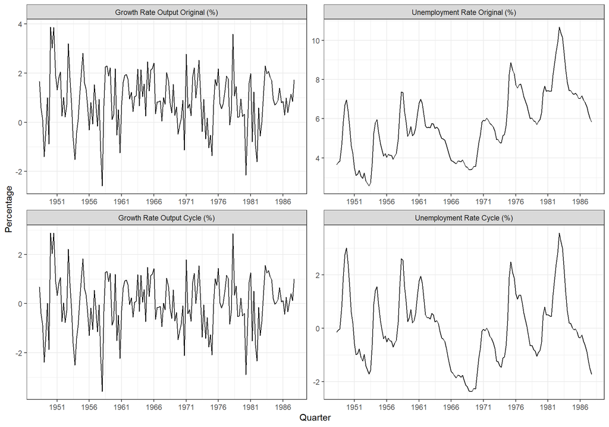

```r
detrend_u <- dynlm(data_set$UNRATE ~ trend(data_set$UNRATE))

# Extract break in GNP data (lower growth rate after 1974)

dummy <- zoo(tstools::create_dummy_ts(end = c(1987,4),
                                  dummy_start = c(1974,1),
                                  dummy_end = c(1987,4),
                                  start_basic  = c(1948,2),
                                  basic_value = 0,
                                  dummy_value = 1,
                                  frequency = 4), order.by = index(data_set))
# Merging all data
data_set <- merge(data_set, dummy)

# Estimation of demean gnp
demean_gnp <- dynlm(data_set$GNPC96 ~ 1 + dummy, data = data_set)

# Extracting the residuals
data_set$gnp <- demean_gnp$residuals

data_set$u <- detrend_u$residuals

# Plotting the data

data_set |>
  data.frame(date = index(data_set)) |>
  dplyr::select(-c("dummy", "period")) |>
  data.table::melt(measure.vars = c(1,2,3,4), variable.name = "variable", value.name = "value") |>
  ggplot(aes(x = date, y = value)) +
  geom_line() +
  facet_wrap( ~ variable, ncol = 2, scale = "free",
            labeller = as_labeller(c(GNPC96 = "Growth Rate Output Original (%)",
                                     UNRATE = "Unemployment Rate Original (%)",
                    gnp = "Growth Rate Output Cycle (%)",
                    u = "Unemployment Rate Cycle (%)"))) +
  labs(x = 'Quarter', y = 'Percentage') +
  theme_bw() +
  scale_x_date(breaks = "5 years", date_labels = "%Y")
```

# 1 Var estimation

```r
information_criteria <- c("AIC", "SC", "HQ")

var_models <- list(var_aic  = NA, var_sc = NA, var_hq = NA)

for(i in seq_along(var_models)){

  var_models[[i]] <- VAR(y = data_set[, c("gnp","u")], lag.max = 20,
                         ic = information_criteria[i])

}

# Table with the Optimal Lag using each Information Criteria
kbl(VARselect(data_set[, c("gnp","u")], lag.max = 20)$selection,
    caption = "Optimal number of Lags by Information Criteria",
    col.names = "Lags", align = "c", booktabs = T) |>
  kable_styling()
```

Optimal number of Lags by Information Criteria

|  | Lags |
| --- | --- |
| AIC(n) | 3 |
| HQ(n) | 2 |
| SC(n) | 2 |
| FPE(n) | 3 |

# 2 Printing the results of the estimations

```r
var8 <- VAR(y = data_set[, c("gnp","u")], p =8, type = "none")

stargazer::stargazer(var8$varresult$gnp,
                     var8$varresult$u,
                     type = "html",
                     dep.var.labels = c("Variation GNP", "Unemployment"),
                     dep.var.labels.include = T)
```

|  | *Dependent variable:* |  |
| --- | --- | --- |
|  | Variation GNP |  |
|  | (1) | (2) |
| gnp.l1 | 0.070 | -0.119*** |
|  | (0.114) | (0.037) |
| u.l1 | -0.915** | 1.321*** |
|  | (0.355) | (0.115) |
| gnp.l2 | 0.095 | -0.111*** |
|  | (0.118) | (0.038) |
| u.l2 | 1.806*** | -0.636*** |
|  | (0.539) | (0.174) |
| gnp.l3 | -0.009 | -0.077* |
|  | (0.122) | (0.039) |
| u.l3 | -0.756 | 0.128 |
|  | (0.564) | (0.182) |
| gnp.l4 | 0.148 | -0.040 |
|  | (0.125) | (0.040) |
| u.l4 | 0.808 | -0.075 |
|  | (0.557) | (0.180) |
| gnp.l5 | 0.085 | -0.004 |
|  | (0.127) | (0.041) |
| u.l5 | -0.804 | 0.209 |
|  | (0.556) | (0.180) |
| gnp.l6 | 0.191 | -0.085** |
|  | (0.126) | (0.041) |
| u.l6 | 0.364 | -0.028 |
|  | (0.558) | (0.180) |
| gnp.l7 | -0.092 | -0.011 |
|  | (0.125) | (0.040) |
| u.l7 | -0.512 | -0.004 |
|  | (0.535) | (0.173) |
| gnp.l8 | 0.016 | 0.004 |
|  | (0.095) | (0.031) |
| u.l8 | 0.237 | 0.025 |
|  | (0.350) | (0.113) |
| Observations | 151 | 151 |
| R<sup>2</sup> | 0.326 | 0.949 |
| Adjusted R<sup>2</sup> | 0.246 | 0.943 |
| Residual Std. Error (df = 135) | 0.942 | 0.304 |
| F Statistic (df = 16; 135) | 4.087*** | 158.428*** |
| *Note:* | p<0.1; p<0.05; p<0.01 |  |

# 3 Identification

We have learned until now two ways of identification. The first one is imposing restriction on the contemporaneous effect between variables by applying restriction on the Cholesky decomposition matrix. The second methods imposes restriction on the long-term relation between the variables, this is the method proposed by (Blanchard and Quah 1988). We will proceed this exercise analyzing both ways of identification.

#### 3.0.0.1 Short term restriction

```r
# Note that the order matters using short-run identification !!!

svar_1 <- VAR(y = data_set[, c(5, 6)], p = 8, type =  "none") |> id.chol()

svar_2 <- VAR(y = data_set[, c(6, 5)], p = 8, type =  "none") |> id.chol()
```

#### 3.0.0.2 Plotting the impulse response function

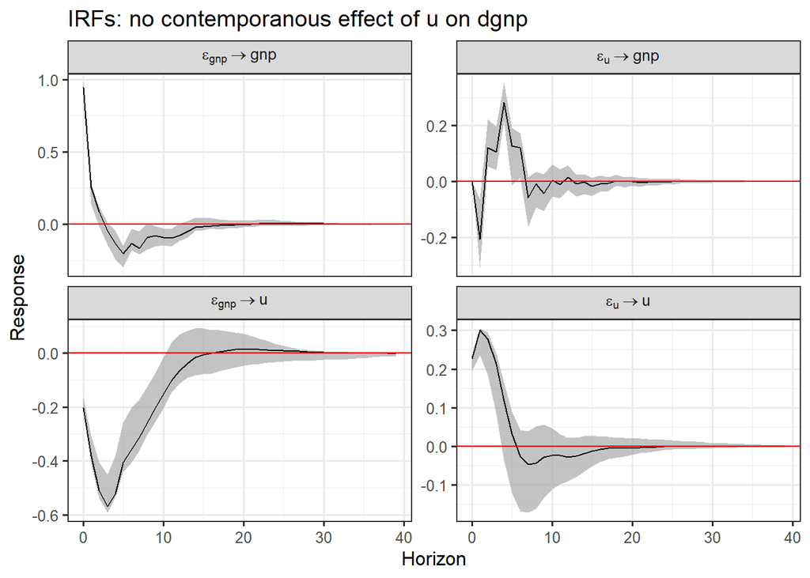

```r
plot(mb.boot(svar_1, n.ahead = 40, nboot = 1000), lowerq = 0.16, upperq = 0.84, distr = "gaussian") +
  theme_bw(base_size = 12) +
  labs(title = 'IRFs: no contemporanous effect of u on dgnp')
```

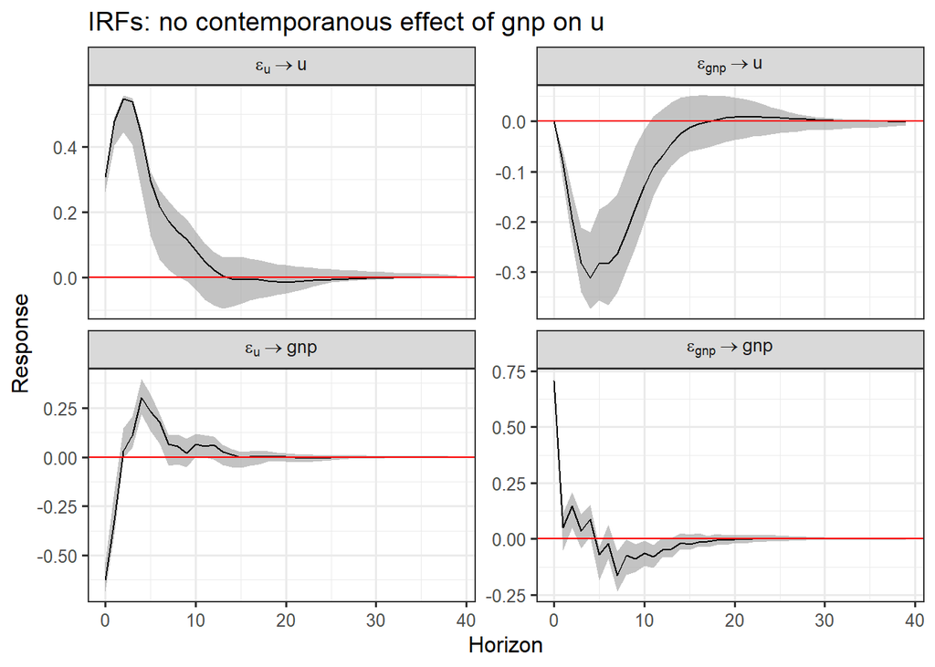

```r
plot(mb.boot(svar_2, n.ahead = 40, nboot = 1000), lowerq = 0.16, upperq = 0.84, distr = "gaussian") +
  theme_bw(base_size = 12) +
  labs(title = 'IRFs: no contemporanous effect of gnp on u')
```

# 4 Long term restriction

We interpret the disturbances that have a **temporary effect** on output as being mostly **demand disturbances**, and those that have a **permanent effect** on output as mostly **supply disturbances**. Note that in order to impose the long-run restriction to identification is used lower-triangular matrix obtained via Choleski decomposition. Therefore, the order of contemporaneous effect matters in the identification.

```r
var_bq <- VAR(y = data_set[, c("gnp", "u")], p = 8, type = "none")

svar_bq <- id.chol(var_bq)

bq_ident <- BQ(var_bq)

summary(bq_ident)
```

```
##
## SVAR Estimation Results:
## ========================
##
## Call:
## BQ(x = var_bq)
##
## Type: Blanchard-Quah
## Sample size: 151
## Log Likelihood: -195.644
##
## Estimated contemporaneous impact matrix:
##        gnp       u
## gnp 0.1734 -0.9260
## u   0.1859  0.2407
##
## Estimated identified long run impact matrix:
##        gnp     u
## gnp 0.4036 0.000
## u   0.1183 4.047
##
## Covariance matrix of reduced form residuals (*100):
##        gnp      u
## gnp  88.76 -19.06
## u   -19.06   9.25
```

```r
# Construction of some useful functions to make plotting easier

irf_bq <- vars::irf(bq_ident, n.ahead = 40, boot = T, ci = 0.68)

irf_bq_cum <- vars::irf(bq_ident, n.ahead = 40, boot = T, ci = 0.68, cumulative = T)

extract_df_irf <- function(model, response, impulse, cumulative){

  irf <- vars::irf(model, n.ahead = 40, boot = T, ci = 0.68,
                   impulse = impulse, response = response, cumulative = cumulative)

  df_irf <- data.frame(irf[["irf"]][[impulse]],
              irf[["Lower"]][[impulse]],
              irf[["Upper"]][[impulse]],
              periods = 1:dim(irf[["irf"]][[1]])[1]) |>
    setNames(c("response", "response_lower", "response_upper", "periods"))

  return(df_irf)
}

plot_irf <- function(model, impulse, response, cumulative, title){

  irf_plot <- ggplot(data = extract_df_irf(model = model, response = response, impulse = impulse, cumulative=cumulative)) +
  geom_line(aes(x = periods,
               y = response))  +
    geom_hline(yintercept = 0, color="red") +
    geom_ribbon(aes(x = periods,
               y = response, ymin = response_lower, ymax = response_upper),
               fill = "grey", alpha = .4,
               color = "grey50", linetype = "dashed") +
    labs(x = "Time", y = "Response") +
    theme_light() +
    ggtitle(title) +
    theme(plot.title = element_text(size = 11, hjust=0.5),
          axis.title.y = element_text(size=11))

  return(irf_plot)
}
```

Making and plotting the IRFs

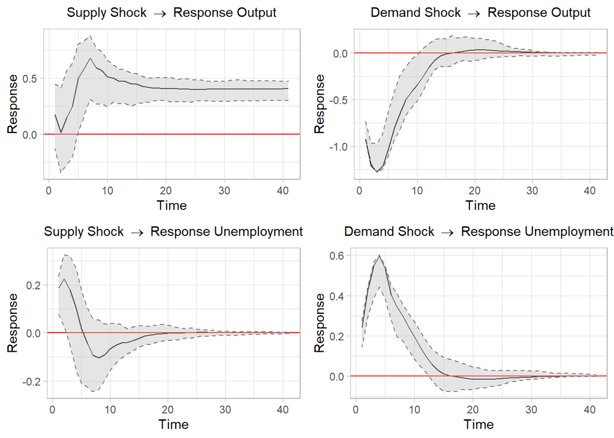

```r
irf_gnp_shock_gnp <- plot_irf(model = bq_ident, impulse = "gnp", response = "gnp", cumulative = T,
                    title = TeX("Supply Shock $\\rightarrow$ Response Output$"))

irf_gnp_shock_unem <- plot_irf(model = bq_ident, impulse = "u", response = "gnp", cumulative = T,
                    title = TeX("Demand Shock $\\rightarrow$ Response Output"))

irf_unem_shock_dgnp <- plot_irf(model = bq_ident, impulse = "gnp", response = "u", cumulative = F,
                    title = TeX("Supply Shock $\\rightarrow$ Response Unemployment"))

irf_unem_shock_unem <- plot_irf(model = bq_ident, impulse = "u", response = "u", cumulative = F,
                    title = TeX("Demand Shock $\\rightarrow$ Response Unemployment"))


# All plots together

gridExtra::grid.arrange(irf_gnp_shock_gnp, irf_gnp_shock_unem,
                        irf_unem_shock_dgnp, irf_unem_shock_unem)
```

### 4.0.1 Main findings

- Demand disturbances have a hump-shaped effect on both output and unemployment;

- The effect peaks after a year and vanishes after two to three years;

- Up to a scale factor, the dynamic effect on unemployment of demand disturbances is a mirror image of that on output;

- The effect of supply disturbances on output increases steadily over time, to reach a peak after two years and a plateau after five years;

- Favorable supply disturbances may initially increase unemployment. This is followed by a decline in unemployment, with a slow return over time to its original value;

# 5 Forecast Error Variance Decomposition (FEVD)

In this section we analyse the contribution of each shock to explain the variance of the forecast.

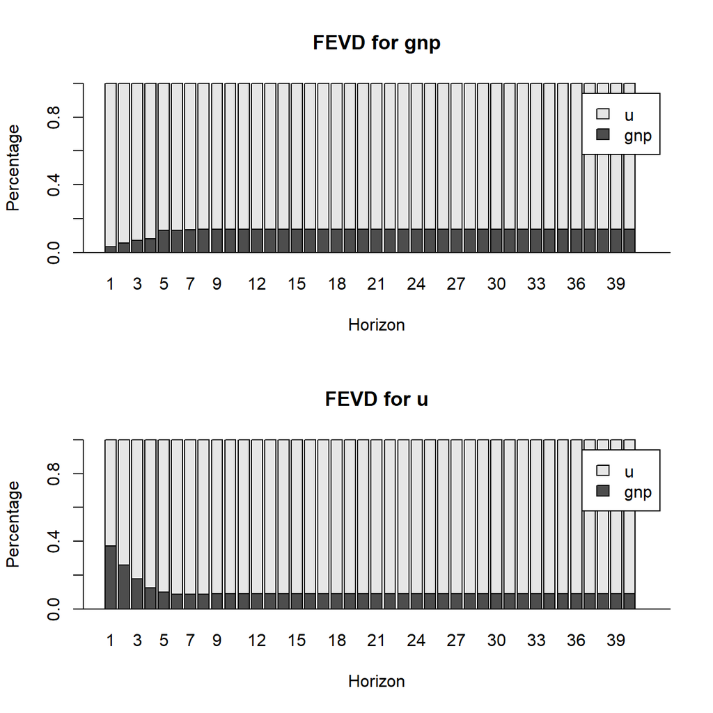

```r
plot(fevd(x = bq_ident, n.ahead = 40))
```

### 5.0.1 Now we need to use the full sample

```r
dt_full <- merge(x = dgnp, u_quartely, join = "inner")["1948-07-01/2021-04-01"] |> as.zoo()

names(dt_full) <- c("gnp", "u")

# Making the transformations

dt_full$dummy <- zoo(tstools::create_dummy_ts(end = c(2021,1),
                                  dummy_start = c(1974,1),
                                  dummy_end = c(2021,1),
                                  start_basic = c(1948,2),
                                  basic_value = 0,
                                  dummy_value = 1,
                                  frequency = 4),
                     order.by = index(dt_full))

# Creating a dummy

# Making the unemployment residuals
dt_full$u_2 <- dynlm(dt_full$u ~ 1 + trend(dt_full$u), data = dt_full) |> residuals()

# Making the structural break on GNP

dt_full$gnp_2 <- dynlm(dt_full$gnp ~ 1 + dummy, data = dt_full) |> residuals()
```

#### 5.0.1.1 Printing the results from VAR using the full sample

**Unrestricted VAR results**

|  | y |  |
| --- | --- | --- |
|  | (1) | (2) |
| gnp.l1 | 0.497*** | -0.350*** |
|  | (0.095) | (0.058) |
| u.l1 | 1.041*** | 0.387*** |
|  | (0.156) | (0.095) |
| gnp.l2 | 0.372*** | -0.218*** |
|  | (0.100) | (0.061) |
| u.l2 | -0.502** | 0.245* |
|  | (0.216) | (0.131) |
| gnp.l3 | 0.118 | -0.108* |
|  | (0.102) | (0.062) |
| u.l3 | -0.146 | 0.125 |
|  | (0.216) | (0.131) |
| gnp.l4 | 0.193* | -0.070 |
|  | (0.100) | (0.061) |
| u.l4 | 0.208 | 0.004 |
|  | (0.213) | (0.129) |
| gnp.l5 | 0.021 | 0.040 |
|  | (0.100) | (0.061) |
| u.l5 | -0.608* | 0.377* |
|  | (0.365) | (0.222) |
| gnp.l6 | 0.079 | 0.039 |
|  | (0.099) | (0.060) |
| u.l6 | 0.192 | 0.004 |
|  | (0.511) | (0.310) |
| gnp.l7 | -0.072 | 0.058 |
|  | (0.101) | (0.061) |
| u.l7 | -0.357 | -0.085 |
|  | (0.506) | (0.308) |
| gnp.l8 | -0.030 | 0.055 |
|  | (0.087) | (0.053) |
| u.l8 | 0.334 | -0.181 |
|  | (0.300) | (0.182) |
| const | -1.092*** | 1.150*** |
|  | (0.392) | (0.238) |
| Observations | 284 | 284 |
| R<sup>2</sup> | 0.209 | 0.863 |
| Adjusted R<sup>2</sup> | 0.161 | 0.855 |
| Residual Std. Error (df = 267) | 1.066 | 0.648 |
| F Statistic (df = 16; 267) | 4.404*** | 105.150*** |
| *Notes:* | ***Significant at the 1 percent level. |  |
|  | **Significant at the 5 percent level. |  |
|  | *Significant at the 10 percent level. |  |

# 6 Using the full sample

```r
bq_ident_full = BQ(var_full)

summary(bq_ident_full)
```

```
##
## SVAR Estimation Results:
## ========================
##
## Call:
## BQ(x = var_full)
##
## Type: Blanchard-Quah
## Sample size: 284
## Log Likelihood: -576.507
##
## Estimated contemporaneous impact matrix:
##         gnp       u
## gnp 0.65486 -0.8415
## u   0.02568  0.6477
##
## Estimated identified long run impact matrix:
##        gnp    u
## gnp  1.270 0.00
## u   -5.436 5.19
##
## Covariance matrix of reduced form residuals (*100):
##        gnp      u
## gnp 113.70 -52.83
## u   -52.83  42.02
```

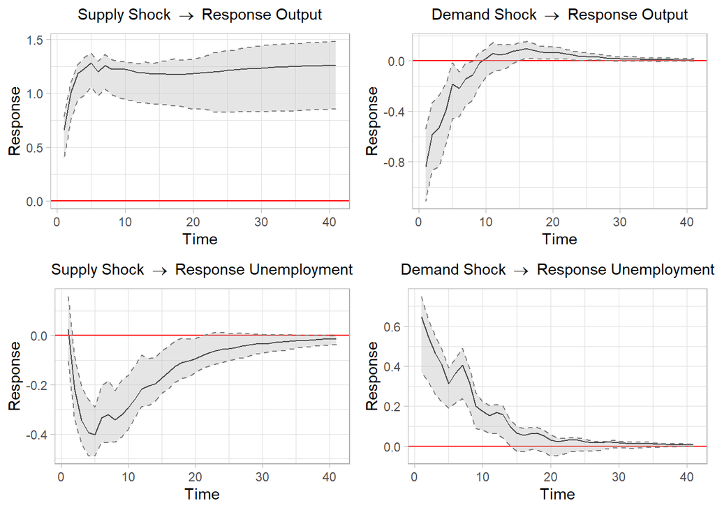

```r
# Non-cumulative and cumulative IRFs

irf_gnp_shock_gnp_full <- plot_irf(model = bq_ident_full, impulse = "gnp", response = "gnp", cumulative = T,
                    title = TeX("Supply Shock $\\rightarrow$ Response Output$"))

irf_gnp_shock_unem_full <- plot_irf(model = bq_ident_full, impulse = "u", response = "gnp", cumulative = T,
                    title = TeX("Demand Shock $\\rightarrow$ Response Output"))

irf_unem_shock_dgnp_full <- plot_irf(model = bq_ident_full, impulse = "gnp", response = "u", cumulative = F,
                    title = TeX("Supply Shock $\\rightarrow$ Response Unemployment"))

irf_unem_shock_unem_full <- plot_irf(model = bq_ident_full, impulse = "u", response = "u", cumulative = F,
                    title = TeX("Demand Shock $\\rightarrow$ Response Unemployment"))



gridExtra::grid.arrange(irf_gnp_shock_gnp_full, irf_gnp_shock_unem_full,
                        irf_unem_shock_dgnp_full, irf_unem_shock_unem_full)
```

# 7 Construction of the counter-factual series

```r
N = 8

# Matrix-Array of the coefficient in the VMA formulation
phi <-  Phi(x = var_bq, nstep = N)

# Matrix with the residual from var estimation using the identification based on
# blanchard and quah

resid_var_bq <- residuals(var_bq)

# Predicting the [gnp, u]^{\prime}
predict_y_demand <- data.frame(t(matrix(NA,
                    nrow = 2,
                    ncol = length(var_bq$varresult$gnp$fitted.values))))

predict_y_supply <- data.frame(t(matrix(NA,
                    nrow = 2,
                    ncol = length(var_bq$varresult$gnp$fitted.values))))

# Upper 1 to supply shock, Lower 1 for demand shock

matrix_shock_supply <- matrix(c(1,0,0,0), ncol=2, nrow =2)

matrix_shock_demand <- matrix(c(0,0,0,1), ncol=2, nrow =2)


# Recursive formula

for(t in 9:length(var_bq$varresult$gnp$fitted.values)){

predict_y_supply_aux = matrix(NA, nrow = 2, ncol = N)

predict_y_demand_aux = matrix(NA, nrow = 2, ncol = N)

for(i in seq_len(N)){

  predict_y_demand_aux[, i]= phi[, , i] %*%
    solve(bq_ident$B) %*% bq_ident$A %*% t(resid_var_bq[t-(i-1),] %*% matrix_shock_demand)

  predict_y_supply_aux[, i]= phi[, , i]  %*%
    solve(bq_ident$B) %*% bq_ident$A %*% t(resid_var_bq[t-(i-1), ] %*% matrix_shock_supply)

}

predict_y_demand[t, 1] <- sum(predict_y_demand_aux[1, ])

predict_y_demand[t, 2] <- sum(predict_y_demand_aux[2, ])

predict_y_supply[t, 1] <- sum(predict_y_supply_aux[1, ])

predict_y_supply[t, 2] <- sum(predict_y_supply_aux[2, ])

}

# Data Set
data_set_cf <- merge(data_set[, c("gnp", "u")],
      xts(predict_y_demand, order.by = index(data_set)[9:159]) ,
      xts(predict_y_supply, order.by = index(data_set)[9:159])) |>
  data.frame() |>
  mutate(date = index(data_set[, c("gnp", "u")])) |>
  setNames(c("gnp", "u", "cf_gnp_demand_shock", "cf_u_demand_shock",
             "cf_gnp_supply_shock", "cf_u_supply_shock", "date"))
```

# 8 Plotting the counter-factual series for output and unemployement

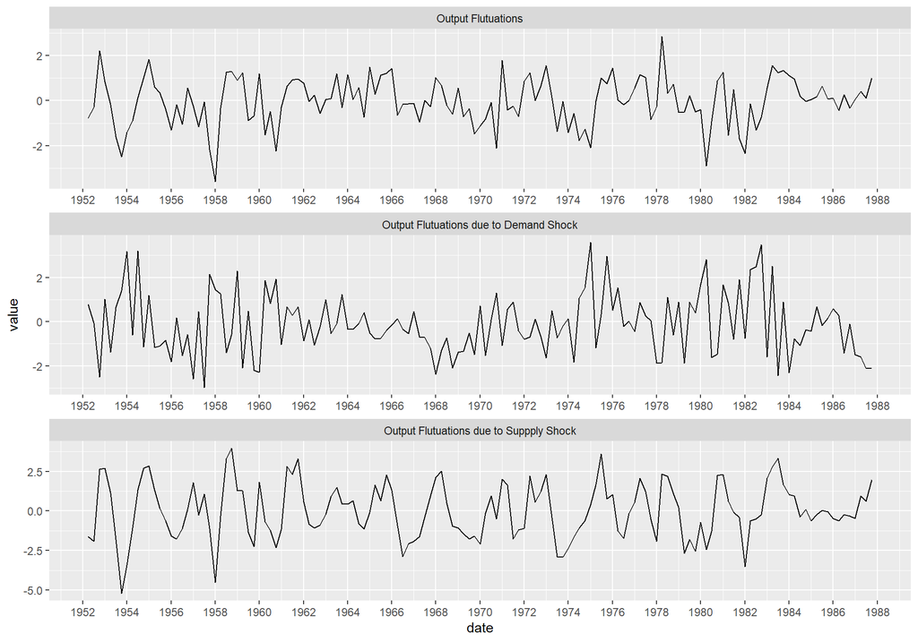

```r
# Plot Output Decomposition
data_set_cf |>
  select(c("date",  "gnp","cf_gnp_demand_shock",  "cf_gnp_supply_shock")) |>
  na.omit() |>
  melt(id.vars = "date", variables.names = "variable", value.name = "value") |>
  ggplot() +
  geom_line(aes(x = date, y = value)) +
  facet_wrap(~variable, ncol = 1, nrow = 3, scale = "free",
             labeller = as_labeller(c(gnp = "Output Flutuations",
                                    cf_gnp_demand_shock = "Output Flutuations due to Demand Shock", cf_gnp_supply_shock = "Output Flutuations due to Suppply Shock"))) +
  theme_grey() +
  scale_x_date(date_labels = "%Y", breaks = "2.5 years")
```

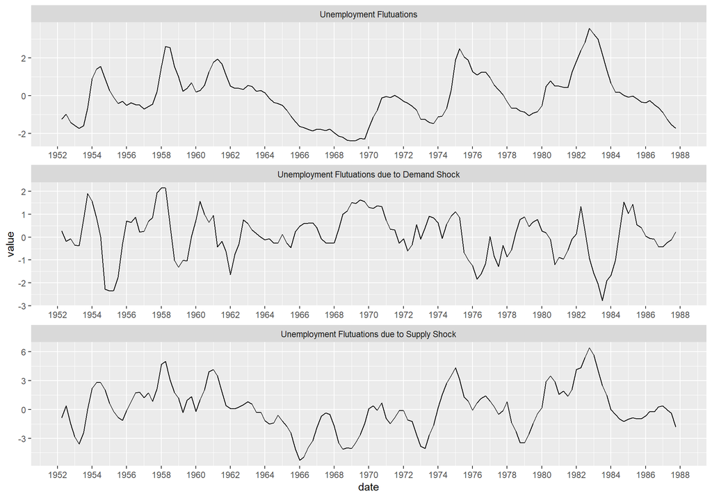

```r
# Plots Unemployment decomposition

data_set_cf |>
  select(c("date","u", "cf_u_demand_shock", "cf_u_supply_shock")) |>
  na.omit() |>
  melt(id.vars = "date", variables.names = "variable", value.name = "value") |>
  ggplot() +
  geom_line(aes(x = date, y = value)) +
  facet_wrap(~variable, ncol = 1, nrow = 3, scale = "free",
             labeller = as_labeller(c(u = "Unemployment Flutuations",
                                    cf_u_demand_shock = "Unemployment Flutuations due to Demand Shock", cf_u_supply_shock = "Unemployment Flutuations due to Supply Shock"))) +
  theme_grey() +
  scale_x_date(date_labels = "%Y", breaks = "2.5 years")
```

# 9 Plotting the counter-factual series for output flutuations in level

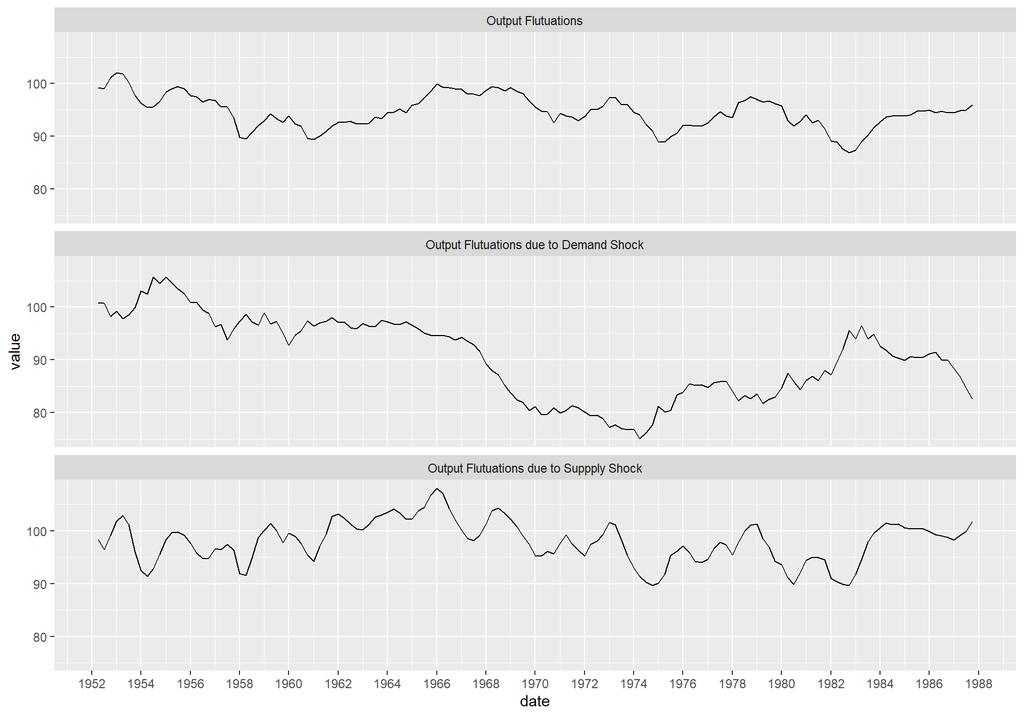

```r
data_set_cf |>
  select(c("date",  "gnp","cf_gnp_demand_shock",  "cf_gnp_supply_shock")) |>
  na.omit() |>
  mutate(gnp = 100*(1+cumsum(gnp)/100),
         cf_gnp_demand_shock = 100*(1+cumsum(cf_gnp_demand_shock)/100),
         cf_gnp_supply_shock = 100*(1+cumsum(cf_gnp_supply_shock)/100)) |>
  melt(id.vars = "date", variable.names = "variable", value.name = "value") |>
  ggplot() +
  geom_line(aes(x = date, y = value)) +
  facet_wrap(~variable, ncol = 1, nrow = 3,
             labeller = as_labeller(c(gnp = "Output Flutuations",
                                    cf_gnp_demand_shock = "Output Flutuations due to Demand Shock", cf_gnp_supply_shock = "Output Flutuations due to Suppply Shock"))) +
  theme_grey() +
  scale_x_date(date_labels = "%Y", breaks = "2.5 years")
```

Blanchard, Olivier Jean, and Danny Quah. 1988. “The Dynamic Effects of Aggregate Demand and Supply Disturbances.” https://doi.org/10.3386/w2737.